**Static export version:** charts render as PNG for GitHub and `nbconvert`. For interactive Plotly, use `modeling_results.ipynb`.

# Incident risk modeling — results

Multi-label prediction: resident-week index `t`, labels = incident types in the **next 30 days**.

Run `python run_pipeline.py` from `tricura_test/` to regenerate artifacts.

## Labeling logic

We predict **incident risk over the next 30 days** on a **resident–time panel** (not one row per resident).

**Unit of analysis.** Each row is a `(resident_id, index_date)` pair: a resident in-facility at weekly index dates from admission until discharge, death, or end of observation. The last index date is at least 30 days before that end date so every row has a full forward window.

**What each label means.** For index date `t` and each type in `LABEL_TYPES` (Fall, Wound, Altercation), the target is **1** if there is **at least one** non-strikeout incident of that type with `occurred_at` in **(t, t + 30 days]**, and **0** otherwise. Multi-label: a row can have none, one, or several types positive.

**Residents with zero incidents.** Residents who never have an incident, and weeks with no event in the forward window, are included with **all labels = 0**. There is no separate “no incident” class.

**Excluded.** Strikeout incidents; types below `MIN_EVENTS_PER_LABEL` (50); residents without `admission_date`.

**Leakage.** Labels use events **after** `t`. Features use only data **strictly before** `t`. Train/test split is **chronological** on `index_date`.

```python
import json
from pathlib import Path
import sys
sys.path.insert(0, str(Path('..').resolve()))

import pandas as pd
import plotly.express as px

import plotly.io as pio
pio.renderers.default = "png"


ROOT = Path('..').resolve()
REPORTS = ROOT / 'reports'

with open(REPORTS / 'split_info.json') as f:
    split_info = json.load(f)
with open(REPORTS / 'metrics.json') as f:
    metrics = json.load(f)
with open(REPORTS / 'counterfactual_comparison.json') as f:
    counterfactual = json.load(f)
with open(REPORTS / 'scenario_summary.json') as f:
    scenario = json.load(f)
with open(REPORTS / 'test_cost_scenario.json') as f:
    test_cost = json.load(f)

benchmark = pd.read_csv(REPORTS / 'model_benchmark.csv')
effects = pd.read_csv(REPORTS / 'feature_effects.csv')
cf_plan = pd.read_csv(REPORTS / 'counterfactual_feature_plan.csv')
cf_selected = pd.read_csv(REPORTS / 'counterfactual_selected_features.csv')

champion = metrics.get('champion_model', metrics.get('model', 'logistic'))
print(f"Champion model (test macro recall): {champion}")
print(f"Benchmark ranking: {metrics.get('benchmark_ranking', [])}")
```

```
Champion model (test macro recall): xgboost
Benchmark ranking: ['xgboost', 'logistic', 'tpot', 'knn']
```

## Train, validation, and test datasets

Chronological split: **train** → **validation** (tuning / early stopping) → **test** (held out). See `split_info['description']` in the next table.

```python
split_labels = {
    'train': 'Train',
    'validation': 'Validation',
    'test': 'Test (held-out)',
}
cohort_rows = []
for split in ('train', 'validation', 'test'):
    s = split_info[split].copy()
    s['split'] = split_labels[split]
    cohort_rows.append(s)
cohort_df = pd.DataFrame(cohort_rows)
print(split_info['description'])
cohort_df
```

[output not shown]

|  | n_rows | n_residents | date_min | date_max | positive_rate_Fall | positive_rate_Wound | positive_rate_Altercation | positive_rate_any | split |
| --- | --- | --- | --- | --- | --- | --- | --- | --- | --- |
| 0 | 65596 | 723 | 2005-02-27 00:00:00 | 2023-09-03 00:00:00 | 0.006525 | 0.001555 | 0.000777 | 0.008354 | Train |
| 1 | 16406 | 874 | 2023-09-10 00:00:00 | 2024-02-25 00:00:00 | 0.071376 | 0.026332 | 0.010118 | 0.101061 | Validation |
| 2 | 35289 | 1459 | 2024-03-03 00:00:00 | 2024-12-29 00:00:00 | 0.078863 | 0.027317 | 0.008785 | 0.107314 | Test (held-out) |

```python
pd.DataFrame({
    'Setting': [
        'Prediction horizon',
        'Index frequency',
        'Train/val cutoff',
        'Val/test cutoff',
        'Label types',
    ],
    'Value': [
        f"{split_info['horizon_days']} days",
        split_info['index_freq'],
        split_info['cutoff_val_start'],
        split_info['cutoff_test_start'],
        ', '.join(split_info['label_types']),
    ],
})
```

|  | Setting | Value |
| --- | --- | --- |
| 0 | Prediction horizon | 30 days |
| 1 | Index frequency | W |
| 2 | Train/val cutoff | 2023-09-10 00:00:00 |
| 3 | Val/test cutoff | 2024-03-03 00:00:00 |
| 4 | Label types | Fall, Wound, Altercation |

## Why precision is low (and why we prioritize recall)

- **Class imbalance:** Most resident-weeks have no incident in the next 30 days (`y_any` is positive on only ~5% of the full panel; higher on the late test slice).
- **Default threshold 0.5** plus **`class_weight="balanced"`** in logistic regression pushes the model to flag more positives → **higher recall, lower precision**.
- **Multi-label:** Subset accuracy requires every type to be correct on a row; one wrong label fails the whole row.
- **Business framing:** For liability screening, **missing a future incident (false negative)** is usually costlier than a **false alert (false positive)**. We **benchmark models by test macro recall** (mean recall across Fall, Wound, Altercation), while still reporting precision, F1, and ROC/PR AUC for context.

## Model benchmark (logistic, XGBoost, KNN, TPOT)

Four multi-label classifiers on the same chronological train / validation / test split. **Champion** = highest **test macro recall** (tie-break: macro F1, macro ROC AUC).

- **Validation** tunes logistic `C`, KNN `k`, XGBoost early stopping, and TPOT pipelines (scoring = recall).
- **KNN** uses a stratified train subsample (`KNN_MAX_TRAIN_ROWS`).
- **TPOT** runs AutoML per label (~8 min/label); can be slow on first pipeline run.

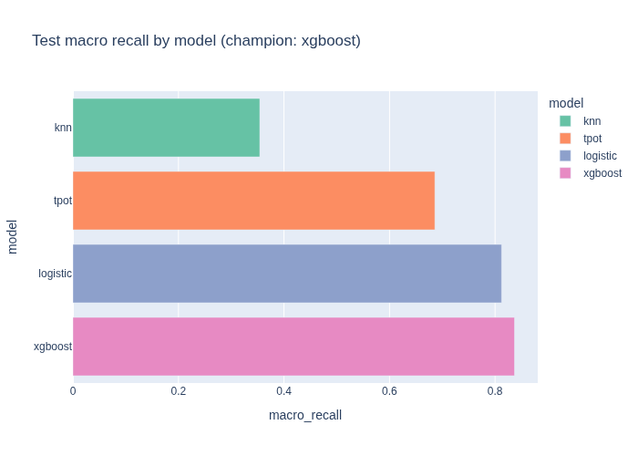

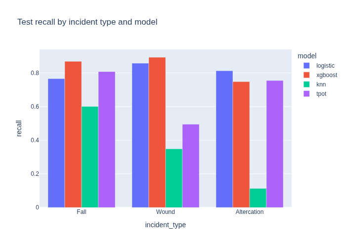

```python
bench_display_cols = [
    'model', 'split', 'macro_recall', 'macro_precision', 'macro_f1',
    'macro_roc_auc', 'hamming_loss', 'subset_accuracy',
]
bench_fmt = benchmark[bench_display_cols].copy()
bench_fmt['split'] = bench_fmt['split'].map({'train': 'Train', 'test': 'Test'})
bench_fmt.round(4)

bench_test = benchmark[benchmark['split'] == 'test'].copy()
fig_bench = px.bar(
    bench_test.sort_values('macro_recall', ascending=True),
    x='macro_recall', y='model', orientation='h',
    title=f'Test macro recall by model (champion: {champion})',
    color='model',
    color_discrete_sequence=px.colors.qualitative.Set2,
)
fig_bench.show()

# Per-label recall on test
recall_cols = [c for c in benchmark.columns if c.startswith('recall_')]
bench_recall_long = bench_test.melt(
    id_vars=['model'], value_vars=recall_cols,
    var_name='incident_type', value_name='recall',
)
bench_recall_long['incident_type'] = bench_recall_long['incident_type'].str.replace('recall_', '').str.replace('_', ' ')
fig_recall = px.bar(
    bench_recall_long, x='incident_type', y='recall', color='model', barmode='group',
    title='Test recall by incident type and model',
)
fig_recall.show()
```

## Champion model — quality metrics

Metrics below are for the **benchmark champion** (`logistic`, `xgboost`, or `knn` by test macro recall). Current champion: see printout in setup cell.

**Train** = in-sample (earlier weeks). **Test** = held-out (later weeks).

- **Recall** (priority): share of true incidents flagged at threshold 0.5
- **Subset accuracy**: all labels correct on a row
- **Hamming loss**: avg wrong labels per row
- **Macro F1**: mean F1 across types

```python
METRIC_COLS = {
    'recall': 'Recall', 'precision': 'Precision', 'roc_auc': 'ROC AUC',
    'pr_auc': 'PR AUC', 'f1': 'F1', 'accuracy': 'Accuracy',
}

def metrics_to_long(split_name):
    block = metrics[split_name]
    rows = []
    for lt, m in block['per_label'].items():
        row = {'Incident type': lt,
               'Dataset': 'Train (in-sample)' if split_name == 'train' else 'Test (held-out)'}
        for k, label in METRIC_COLS.items():
            row[label] = m.get(k)
        rows.append(row)
    return pd.DataFrame(rows)

metrics_long = pd.concat([metrics_to_long('train'), metrics_to_long('test')], ignore_index=True)
metrics_long
```

|  | Incident type | Dataset | Recall | Precision | ROC AUC | PR AUC | F1 | Accuracy |
| --- | --- | --- | --- | --- | --- | --- | --- | --- |
| 0 | Fall | Train (in-sample) | 0.509346 | 0.106134 | 0.894892 | 0.080881 | 0.175665 | 0.968809 |
| 1 | Wound | Train (in-sample) | 0.725490 | 0.012519 | 0.900744 | 0.024238 | 0.024613 | 0.910589 |
| 2 | Altercation | Train (in-sample) | 0.705882 | 0.015471 | 0.938935 | 0.026910 | 0.030278 | 0.964845 |
| 3 | Fall | Test (held-out) | 0.868847 | 0.114880 | 0.685723 | 0.128088 | 0.202929 | 0.461730 |
| 4 | Wound | Test (held-out) | 0.893154 | 0.040495 | 0.676360 | 0.042587 | 0.077477 | 0.418969 |
| 5 | Altercation | Test (held-out) | 0.748387 | 0.013986 | 0.676010 | 0.013704 | 0.027459 | 0.534302 |

```python
summary_rows = []
for split_name, label in [('train', 'Train (in-sample)'), ('test', 'Test (held-out)')]:
    s = metrics[split_name]['summary']
    summary_rows.append({
        'Dataset': label,
        'Macro recall': s['macro_recall'],
        'Macro precision': s['macro_precision'],
        'Subset accuracy': s['subset_accuracy'],
        'Hamming loss': s['hamming_loss'],
        'Micro F1': s['micro_f1'],
        'Macro F1': s['macro_f1'],
        'Macro ROC AUC': s.get('macro_roc_auc'),
    })
pd.DataFrame(summary_rows)
```

|  | Dataset | Macro recall | Macro precision | Subset accuracy | Hamming loss | Micro F1 | Macro F1 | Macro ROC AUC |
| --- | --- | --- | --- | --- | --- | --- | --- | --- |
| 0 | Train (in-sample) | 0.646906 | 0.044708 | 0.882584 | 0.051919 | 0.060333 | 0.076852 | 0.911524 |
| 1 | Test (held-out) | 0.836796 | 0.056454 | 0.319051 | 0.528333 | 0.111540 | 0.102622 | 0.679364 |

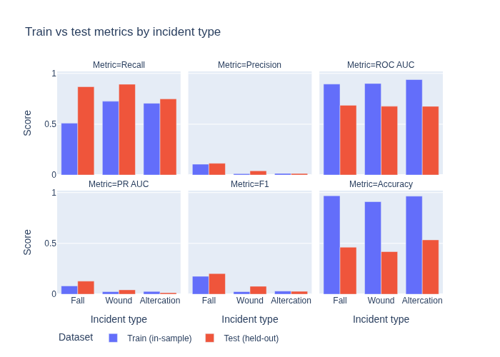

```python
plot_df = metrics_long.melt(
    id_vars=['Incident type', 'Dataset'],
    value_vars=list(METRIC_COLS.values()),
    var_name='Metric', value_name='Score',
)
fig_metrics = px.bar(
    plot_df, x='Incident type', y='Score', color='Dataset',
    facet_col='Metric', facet_col_wrap=3, barmode='group',
    title='Train vs test metrics by incident type',
)
fig_metrics.update_layout(height=500, legend=dict(orientation='h', y=-0.15))
fig_metrics.show()
```